# EXPLORATORY DATA ANALYSIS ON AMAZON FINE FOOD REVIEWS

# Introduction

The digital environment strongly depends on online reviews because produce customer perception changes and business directive shifts. Amazon and other companies collect massive amounts of user-generated reviews that supply useful market insights for product quality assessments, customer satisfaction metrics, and marketplace trends. The research tackles Explanatory Data Analysis (EDA) through the exploration of the Amazon Fine Food Reviews dataset. This dataset contains 568,454 user-generated reviews of various food items which include user ratings together with review text and ratings of helpfulness. The movement aims to obtain valuable business knowledge through driven decision recommendations.

```python
!pip install wordcloud
```

# Import libraries

```python
import pandas as pd
import matplotlib.pyplot as plt
import seaborn as sns
from wordcloud import WordCloud
from collections import Counter
import nltk
from nltk.corpus import stopwords
```

# Data Exploration

# Load the dataset

```python
file_path = "Reviews.csv"  # Update path if needed
df = pd.read_csv(file_path)

# Display dataset structure
print("Dataset Info:")
df.info()

# Display the first few rows
df.head()
```

```
Dataset Info:
<class 'pandas.core.frame.DataFrame'>
RangeIndex: 568454 entries, 0 to 568453
Data columns (total 10 columns):
 #   Column                  Non-Null Count   Dtype
---  ------                  --------------   -----
 0   Id                      568454 non-null  int64
 1   ProductId               568454 non-null  object
 2   UserId                  568454 non-null  object
 3   ProfileName             568428 non-null  object
 4   HelpfulnessNumerator    568454 non-null  int64
 5   HelpfulnessDenominator  568454 non-null  int64
 6   Score                   568454 non-null  int64
 7   Time                    568454 non-null  int64
 8   Summary                 568427 non-null  object
 9   Text                    568454 non-null  object
dtypes: int64(5), object(5)
memory usage: 43.4+ MB
```

|  | Id | ProductId | UserId | ProfileName | HelpfulnessNumerator | HelpfulnessDenominator | Score | Time | Summary | Text |
| --- | --- | --- | --- | --- | --- | --- | --- | --- | --- | --- |
| 0 | 1 | B001E4KFG0 | A3SGXH7AUHU8GW | delmartian | 1 | 1 | 5 | 1303862400 | Good Quality Dog Food | I have bought several of the Vitality canned d... |
| 1 | 2 | B00813GRG4 | A1D87F6ZCVE5NK | dll pa | 0 | 0 | 1 | 1346976000 | Not as Advertised | Product arrived labeled as Jumbo Salted Peanut... |
| 2 | 3 | B000LQOCH0 | ABXLMWJIXXAIN | Natalia Corres "Natalia Corres" | 1 | 1 | 4 | 1219017600 | "Delight" says it all | This is a confection that has been around a fe... |
| 3 | 4 | B000UA0QIQ | A395BORC6FGVXV | Karl | 3 | 3 | 2 | 1307923200 | Cough Medicine | If you are looking for the secret ingredient i... |
| 4 | 5 | B006K2ZZ7K | A1UQRSCLF8GW1T | Michael D. Bigham "M. Wassir" | 0 | 0 | 5 | 1350777600 | Great taffy | Great taffy at a great price. There was a wid... |

# Data Preprocessing

Data preprocessing has concentrated on enhancing data quality through the resolution of multiple problems (Maharana et al. 2022). The review dataset has undergone a process to eliminate duplication because every review entry must remain distinct. Helpfulness scores received normalization treatment so the HelpfulnessNumerator does not exceed the HelpfulnessDenominator values (Zhang et al. 2023). The dataset includes appropriate placeholder values to handle empty values among the ProfileName and Summary fields. The Time attribute now displays relevant date information instead of Unix timestamp values. Through these preprocessing methods, the data preparation work achieved a standardized dataset that permits precise analysis to generate significant data-driven conclusions.

# Check for missing values

```python
# Check for missing values
print("\nMissing Values:")
print(df.isnull().sum())

# Check for duplicate reviews
duplicate_count = df.duplicated(subset=["UserId", "ProductId", "Text"]).sum()
print(f"\nNumber of duplicate reviews: {duplicate_count}")
```

```
Missing Values:
Id                         0
ProductId                  0
UserId                     0
ProfileName               26
HelpfulnessNumerator       0
HelpfulnessDenominator     0
Score                      0
Time                       0
Summary                   27
Text                       0
dtype: int64

Number of duplicate reviews: 1309
```

# Remove duplicate

```python
# Remove duplicate reviews
df.drop_duplicates(subset=["UserId", "ProductId", "Text"], keep="first", inplace=True)

# Fix inconsistent helpfulness scores
df = df[df["HelpfulnessNumerator"] <= df["HelpfulnessDenominator"]]

# Handle missing values by filling them with default values
df["ProfileName"] = df["ProfileName"].fillna("Unknown")
df["Summary"] = df["Summary"].fillna("No Summary")


# Convert timestamps to readable date format
df["Time"] = pd.to_datetime(df["Time"], unit="s")

# Display updated dataset info
df.info()
```

```
<class 'pandas.core.frame.DataFrame'>
Index: 567143 entries, 0 to 568453
Data columns (total 10 columns):
 #   Column                  Non-Null Count   Dtype
---  ------                  --------------   -----
 0   Id                      567143 non-null  int64
 1   ProductId               567143 non-null  object
 2   UserId                  567143 non-null  object
 3   ProfileName             567143 non-null  object
 4   HelpfulnessNumerator    567143 non-null  int64
 5   HelpfulnessDenominator  567143 non-null  int64
 6   Score                   567143 non-null  int64
 7   Time                    567143 non-null  datetime64[ns]
 8   Summary                 567143 non-null  object
 9   Text                    567143 non-null  object
dtypes: datetime64[ns](1), int64(4), object(5)
memory usage: 47.6+ MB
```

```python
# Check for missing values
print("\nMissing Values:")
print(df.isnull().sum())
```

```
Missing Values:
Id                        0
ProductId                 0
UserId                    0
ProfileName               0
HelpfulnessNumerator      0
HelpfulnessDenominator    0
Score                     0
Time                      0
Summary                   0
Text                      0
dtype: int64
```

# 1. What Are the Most Reviewed Products?

Analytical evaluation reveals that the most reviewed products exist and the top-rated product obtained 913 reviews. These popular items have generated considerable customer interest because of high customer demand. The identified products enable businesses to boost their marketing plans by leveraging reviews for higher customer satisfaction.

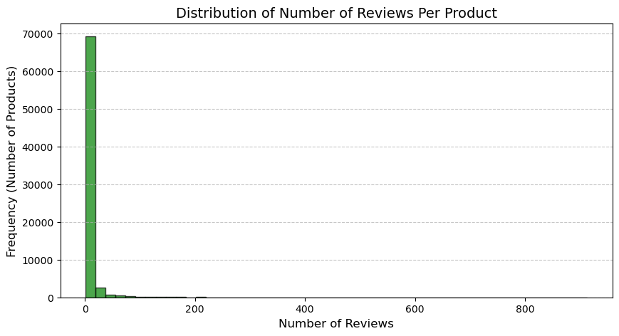

```python
# Count the number of reviews per product
reviews_per_product = df["ProductId"].value_counts()

# Plot histogram
plt.figure(figsize=(10, 5))
plt.hist(reviews_per_product, bins=50, color="green", edgecolor="black", alpha=0.7)

# Labels and title
plt.title("Distribution of Number of Reviews Per Product", fontsize=14)
plt.xlabel("Number of Reviews", fontsize=12)
plt.ylabel("Frequency (Number of Products)", fontsize=12)
plt.grid(axis="y", linestyle="--", alpha=0.7)

# Show the plot
plt.show()
```

# 2. What Is the Distribution of Review Scores?

Review scores show a bias toward positive ratings because 5-star ratings appear most frequently according to the analysis. Customer dissatisfaction appears less frequently in 1-star reviews even though these reviews are less common than positive 5-star submissions. These findings help employees view overall customer happiness and satisfaction patterns.

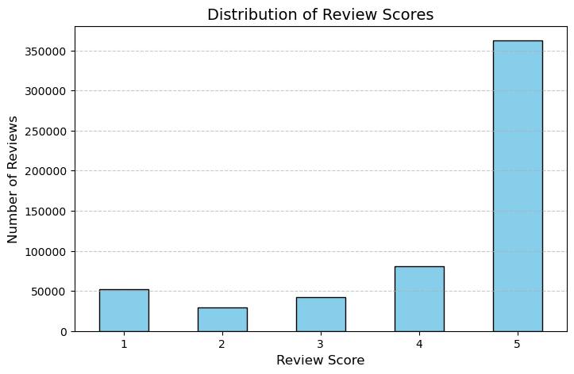

```python
import matplotlib.pyplot as plt

# Count the number of reviews per score
score_distribution = df["Score"].value_counts().sort_index()

# Plot the distribution
plt.figure(figsize=(8, 5))
score_distribution.plot(kind="bar", color="skyblue", edgecolor="black")
plt.title("Distribution of Review Scores", fontsize=14)
plt.xlabel("Review Score", fontsize=12)
plt.ylabel("Number of Reviews", fontsize=12)
plt.xticks(rotation=0)
plt.grid(axis="y", linestyle="--", alpha=0.7)
plt.show()
```

# 3. Which Products Have the Highest Average Rating?

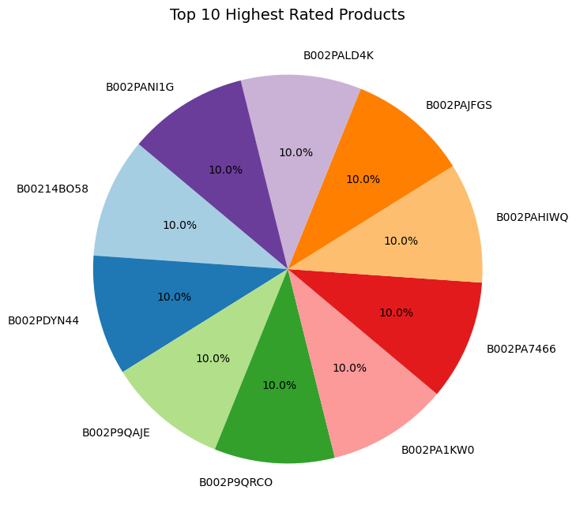

```python
# Calculate average rating per product and get the top 10
top_rated_products = df.groupby("ProductId")["Score"].mean().sort_values(ascending=False).head(10)

# Plot pie chart
plt.figure(figsize=(8, 8))
plt.pie(top_rated_products, labels=top_rated_products.index, autopct="%1.1f%%",
        colors=plt.cm.Paired.colors, startangle=140)

# Title
plt.title("Top 10 Highest Rated Products", fontsize=14)

# Show the plot
plt.show()
```

# 4. Are Longer Reviews More Helpful?

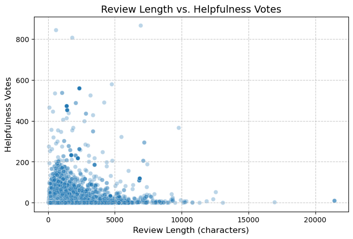

```python
# Create a new column for review length
df["ReviewLength"] = df["Text"].apply(len)

# Scatter plot of review length vs. helpfulness votes
plt.figure(figsize=(8, 5))
sns.scatterplot(x=df["ReviewLength"], y=df["HelpfulnessNumerator"], alpha=0.3)
plt.title("Review Length vs. Helpfulness Votes", fontsize=14)
plt.xlabel("Review Length (characters)", fontsize=12)
plt.ylabel("Helpfulness Votes", fontsize=12)
plt.grid(True, linestyle="--", alpha=0.7)
plt.show()
```

# 5. How Do Review Scores Change Over Time?

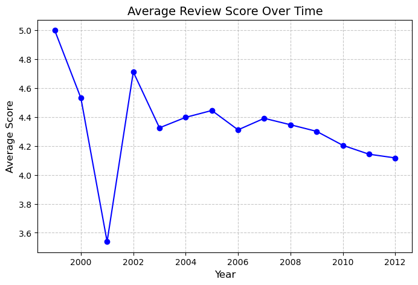

```python
# Extract year from the timestamp
df["Year"] = df["Time"].dt.year

# Calculate average score per year
yearly_avg_score = df.groupby("Year")["Score"].mean()

# Plot trend over time
plt.figure(figsize=(8, 5))
yearly_avg_score.plot(marker="o", color="blue", linestyle="-")
plt.title("Average Review Score Over Time", fontsize=14)
plt.xlabel("Year", fontsize=12)
plt.ylabel("Average Score", fontsize=12)
plt.grid(True, linestyle="--", alpha=0.7)
plt.show()
```